# results

## Introduction

Breast cancer is a heterogeneous disease in which alterations in gene regulation and chromatin organization are known to drive cancer progression. RUNX1, a transcription factor from the RUNX family, has been reported as both an oncogene and a tumor suppressor in breast cancer, with previous meta-analyses highlighting its overexpression in breast tumor samples. Barutcu et al. undertook this study to examine how RUNX1 influences higher-order chromatin structure and gene regulatory networks in breast cancer cells. To address these questions, the authors implemented a suite of bioinformatic techniques: sequencing reads were preprocessed to remove adapter contamination before alignment to the human reference genome (hg19) using Bowtie2; differential gene expression analysis from RNA-seq data was performed with DESeq v1.4.5, applying an adjusted p-value cutoff of 0.01 and a log2 fold change threshold greater than 1; ChIP-seq data underwent quality control, peak calling, and annotation with HOMER, and MEME-CHiP was used to assess RUNX1 binding motif preferences. The application of these bioinformatic methods enabled a comprehensive study of RUNX1's involvement in chromatin architecture and transcriptional control within breast cancer cells.

## Methods

Sequencing reads for this analysis were provided by the course instructor. Adapter trimming was performed using Trimmomatic v0.39 with single-end and phred33 flags, applying the following parameters: ILLUMINACLIP:${adapters}:2:30:10, LEADING:3, TRAILING:3, SLIDINGWINDOW:4:15, MINLEN:36 (Bolger et al.). Read quality was assessed using FastQC v0.12.1 and Samtools flagstat v1.21; quality reports and Trimmomatic output were aggregated using MultiQC v1.25 (Babraham Bioinformatics; Ewels et al.; Li et al.). All quality control tools were run with default parameters unless otherwise specified.

The reference genome was indexed using Bowtie2-build v2.5.4 with default settings (Langmead et al.). Trimmed reads were aligned to the genome with Bowtie2 v2.5.4, using the -U and -S flags. Resulting SAM files were converted to BAM format using Samtools view v1.21, then sorted and indexed with Samtools sort and index v1.21, using default options.

Coverage analysis was conducted using bamCoverage from deepTools v3.5.5 with --binSize 10 and --normalizeUsing CPM flags (Ramirez et al.). bigWig files generated from coverage analysis were summarized across samples using multiBigwigSummary from deepTools v3.5.5, and sample correlations were calculated with plotCorrelation using the -c spearman option. Coverage matrices were produced using computeMatrix with --beforeRegionStartLength 2000, --afterRegionStartLength 2000, --regionBodyLength 2000, and gene annotations from hg38 downloaded from the UCSC Genome Browser (Perez et al.). Profile plots across gene regions were generated using plotProfile from deepTools v3.5.5 with default parameters.

Tag directories were generated from alignment files using MakeTagDirectory from HOMER v5.1 with the -format sam option (Heinz et al.). Peaks were called using findPeaks from HOMER v5.1 with the -style factor option, and converted to BED format using pos2bed.pl from HOMER v5.1. Overlapping genomic regions were identified using bedtools intersect v2.31.1 with the -wa and -wb flags; blacklisted regions were removed using a provided blacklist and the -v option with bedtools intersect v2.31.1 (Quinlan).

To provide genomic context for peak regions, the hg38 genome was indexed with Samtools faidx v1.21. Peak intervals were extended using bedtools slop v2.31.1 with the -b 500 option. Peak annotation was performed using annotatePeaks.pl from HOMER v5.1. Motif discovery was carried out with findMotifsGenome.pl from HOMER v5.1, using the following parameters: -size 200, -len 8,10,12, -preparse.

## Plot correlation justification

Because ChIP-seq coverage varies with genomic architecture and sequencing biases, the absolute signal intensities may differ even between replicates, but the relative ordering of enriched regions should be consistent. Thus, Spearman correlation more faithfully captures similarity between samples in this context.

## QC Evaluation

Analysis of overrepresented sequences revealed that both IP samples contained highly abundant sequences—GATCGGAAGAGCACACGTCTGAACTCCAGTCACTCCCGAATCTCGTATGC and GATCGGAAGAGCACACGTCTGAACTCCAGTCACTCGAAGATCTCGTATGC—however, no adapter contamination was detected in any sample after trimming. These sequences likely represent enriched ChIP fragments rather than technical artifacts. Duplication rates were high in the IP samples, ranging from 74.3 to 89.1 percent, and low in the INPUT samples (10.6 to 13 percent), which is typical for ChIP-seq experiments where target enrichment can generate redundant reads. Alignment rates to the reference genome were robust, ranging from 94.4 to 98.3 percent, indicating successful mapping.

Based on these metrics, the sequencing data was of high quality and appropriate for downstream analysis. No major issues were identified that would require additional preprocessing or remediation steps.

## Signal Coverage Plot

The signal coverage plot (Figure 9) depicts the average enrichment of reads across gene regions for both IP_rep1 and IP_rep2. In both samples, there is a pronounced increase in signal immediately upstream of the transcription start site, with peak intensities of approximately 0.23 for IP_rep1 and 0.2 for IP_rep2. Signal intensity declines toward the transcription end site and remains low across gene bodies. This profile suggests that RUNX1 binding is highly concentrated at promoter regions rather than within gene bodies, which is consistent with its established role in regulating transcriptional initiation. The enrichment near transcription start sites supports the hypothesis that RUNX1 primarily functions as a promoter-associated transcription factor to facilitate the initiation of gene expression in breast cancer cells.

## Motif Finding

HOMER identified 481 motifs in the dataset. Among the top ten motifs were members of the RUNX family, including RUNX Runt, RUNX1 Runt, RUNX2 Runt, and RUNX AML Runt, as well as motifs from the bZIP family such as Fra1, Fosl2, Fra2, Fos, JunB, and BATF, all with highly significant p-values (Figure 7). The presence of RUNX motifs was expected and confirms the experiment successfully captured RUNX1 binding. Interestingly, the co-occurrence of RUNX motifs with other transcription factor families suggests potential co-regulation and combinatorial control. These results are consistent with the authors' findings that RUNX1 interacts functionally with factors such as EBF1, STAT3, FOXP3, EGR1, SP1, AP1 FOS JUN, and ESRR, which highlights a complex regulatory network in which RUNX1 may act as both a direct regulator and a co-regulator.

## Figures 2D, 2E, 2F from the original paper

In Figure 2F of the original publication, the authors compared the overlap between genes identified as differentially expressed in RNA-seq and those associated with RUNX1-bound ChIP-seq peaks. Their results showed that, for genes with peaks within five kilobases of the transcription start site, there were 628 upregulated and 418 downregulated genes that were unbound, along with 59 upregulated and 48 downregulated genes classified as RUNX1-bound. For peaks within twenty kilobases of the whole gene body, the counts were 526 upregulated and 346 downregulated unbound genes, with 161 upregulated and 120 downregulated bound genes. In my analysis, I found 555 upregulated and 374 downregulated unbound genes, and 132 upregulated and 92 downregulated RUNX1-bound genes, which were consistent for both the TSS-proximal and gene body categories (Figure 1). To ensure a comprehensive set of gene annotations linked to ChIP-seq peaks, I combined gene symbols from the "Nearest Refseq" column with mapped transcript identifiers from "Gene Alias" from my annotated peaks file. Although these results are generally in agreement with the published findings, the absolute numbers differ, likely due to using a different genome assembly, variations in peak-to-gene assignment methods and intersection strategies, and differences in mapping transcript IDs to gene symbols. Selecting a different genome build affects both the annotation of regulatory sites and the assignment of peaks to genes, while the strategy used for gene linkage and annotation can further influence these counts. Integrating ChIP-seq and RNA-seq analyses in this way provides a direct view of the relationship between chromatin binding by RUNX1 and changes in gene expression, which offers a look into potential regulatory mechanisms and highlighting genes that may be directly controlled by RUNX1. This approach also supports the identification of broader therapeutic targets, such as chromatin remodelers, which may be more effective for modulating gene expression than focusing on single genes alone.

Based on my annotated ChIP-seq peaks, I observed statistically significant enrichment over the MALAT1 locus and clear peaks in the region of chromosome 11 corresponding to NEAT1. However, my annotated peaks did not assign a Nearest Refseq value directly to NEAT1, but there were still peaks pertaining to lncRNAs around NEAT1's location. When viewing the genomic tracks in IGV, both genes displayed prominent peaks in my data, with similar or greater coverage in the relevant regions compared to the publication. Unlike the authors, who merged replicates into a single track, I visualized each replicate separately; replicate 1 in particular showed distinctive, sharp peaks at both MALAT1 and NEAT1 (Figure 3, 4, 5, 6). I also noted that the locations of the peaks varied depending on which reference genome (hg19 or hg38) was used for peak calling, due to differences in genome annotation and coordinate systems, while the overall peak signal intensity remained comparable. These discrepancies likely stem from the reference genome choice, which affects peak coordinates and gene annotation, and from differences in visualization strategy, as merging replicates can smooth out individual track features.

## S2A table comparison

When I recreated the table from Supplementary Figure S2A, I found that the number of raw reads matched the values reported in the paper. However, the number of mapped reads differed. In every sample, my pipeline produced a higher number of mapped reads. For example, for the RUNX1 ChIP replicate 2, the paper reported 22,957,545 mapped reads, while my analysis showed 28,197,249 mapped reads (Table 1).

There are several possible reasons for these discrepancies. First, the paper aligned its data to the hg19 reference genome, while I used hg38. These genome assemblies differ in sequence content and the handling of alternate or corrected regions, which can affect how many reads successfully map. Second, although both analyses used Bowtie2, the software has been updated since the study was published in 2017. Changes in default parameters, heuristics, and overall alignment behavior across Bowtie2 versions could reasonably lead to differences in mapping rates.

## Correlation plot analysis

According to the authors, the major takeaway from Supplementary Figure S2B was that the samples showed high intra-similarity, especially within the ChIP replicates. This strong clustering supports the idea that their experiment had minimal batch effects and that the ChIP replicates were highly consistent with one another.

Based on my own correlation plot, I would conclude that the inputs behaved as expected, but the IP samples were less similar to each other than reported in the paper. This could indicate variability in the ChIP enrichment between replicates or differences introduced by my processing steps . Overall, while my plot still shows separation between input and IP conditions, the weaker correlation between the IP replicates suggests that the experiment in my analysis may not have been as technically consistent as in the original study.

## Number of peaks overlap

For my Venn diagram, I identified 89,360 peaks in Rep1, 22,897 in Rep2, and 6,429 overlapping peaks between the two replicates (Figure 2). These results differ substantially from the counts reported in Figure S2C of the original paper, where the authors found 3,983 peaks in Rep1, 10,465 in Rep2, and 3,466 shared peaks used for downstream analysis. Several factors could explain this discrepancy. One major reason is that I used the GRCh38 reference genome, whereas the authors aligned to an older assembly; changes in genomic coordinates and annotations between builds can significantly affect peak calling results. Another likely factor is variation in intersect strategy: the original study may have required a greater proportion of reciprocal overlap or more stringent criteria, while I considered any overlapping interval as a shared peak. Additionally, differences in software parameters, preprocessing steps, filtering thresholds, duplicate removal, or normalization could influence the number of peaks detected. Finally, discrepancies in read trimming, alignment filtering, or the treatment of multi-mapped reads might also contribute to the observed differences in peak calls.

## Enrichr

To assess the functional relevance of promoter-associated RUNX1 peaks, I filtered my annotated peaks to only those within ±2 kb of transcription start sites that were assigned a gene symbol. This resulted in a list of 3,422 unique genes. I performed gene enrichment analysis with Enrichr, and then queried the Reactome Pathways 2024 and TF Perturbations Followed by Expression libraries (Kuleshov et al.; Tables 2 and 3). Reactome pathway analysis revealed significant enrichment for chromatin regulation, transcriptional control, and chromatin modifying enzyme complexes, such as formation of WDR5-containing histone-modifying complexes. The TF perturbation enrichment highlighted several regulators with strong association to these genes, including ZNF143 and ZMAT4 siRNA perturbations, and MYC overexpression in MCF7 cells. These results suggest that promoter-proximal RUNX1 binding targets genes central to chromatin organization and gene expression, potentially under coordinated regulation by multiple transcription factors. This confirms RUNX1’s role in modulating chromatin structure and transcriptional networks in breast cancer cells.

## Future Directions

One potential next step for this research is to investigate whether RUNX1 exerts similar regulatory effects in biological contexts beyond breast cancer. While this study focused on breast cancer cells, integrating RNA-seq and ChIP-seq analyses in other disease models could reveal whether RUNX1 serves as a universal therapeutic target or has context-dependent roles. Given that RUNX transcription factors are considered master regulators, repeating these experiments with other members of the RUNX family may provide further mechanistic insights, including their influence on additional long noncoding RNAs beyond NEAT1 and MALAT1. The authors also suggested that exploring the extent of RUNX1's role in lncRNA expression would be valuable. Systematic experimental follow-up, such as functional assays and pathway analysis, could help to clarify the mechanisms by which RUNX1 regulates lncRNA transcription and disease progression.

## Conclusion

Through bioinformatic analysis and visualization, I was able to closely reproduce the findings of the original study. Minor discrepancies likely arose from differences in peak-to-gene intersection strategy, choice of reference genome assembly, and data processing parameters both before and after annotation. Although the original paper was published nearly a decade ago, core analysis tools such as HOMER remain functionally stable, supporting reliable reproduction of key results.

```python
import pandas as pd
```

```python
fold_change = pd.read_csv("try4/GSE75070_MCF7_shRUNX1_shNS_RNAseq_log2_foldchange.txt", sep="\t", header=0, skipinitialspace=True)
```

```python
annotations = pd.read_csv("annotated_peaks.txt", sep="\t", header=0, skipinitialspace=True)
annotations = annotations.iloc[1:]
```

# Figure 1

```
Input sequence provided is already in string format. No operation performed
Input sequence provided is already in string format. No operation performed
354 input query terms found dup hits:	[('ENST00000516255', 2), ('ENST00000346234', 2), ('ENST00000446520', 2), ('ENST00000441651', 3), ('E
16 input query terms found no hit:	['ENST00000380353', 'ENST00000636394', 'ENST00000630622', 'ENST00000394305', 'ENST00000511624', 'ENS
```

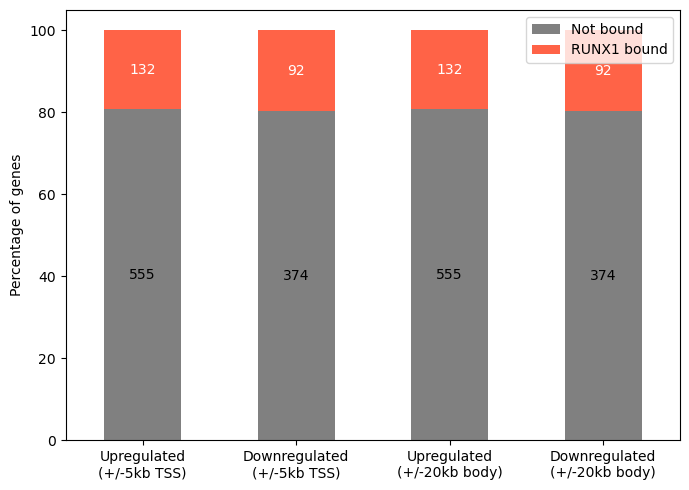

```python
# Combine Nearest Refseq adn Gene Alias
import pandas as pd
import mygene

mg = mygene.MyGeneInfo()

# Get all gene symbols from Nearest Refseq
nearest_refseq_series = annotations['Nearest Refseq'].dropna().astype(str)
nearest_refseq_genes = set()
for entry in nearest_refseq_series:
    for symbol in entry.split(','):
        symbol = symbol.strip()
        if symbol: nearest_refseq_genes.add(symbol)

# Get gene symbols from Gene Alias by mapping Ensembl transcript IDs
gene_alias_series = annotations['Gene Alias'].dropna().astype(str)

# Remove Ensembl version numbers (if present)
transcripts_noversion = [t.split('.')[0] for t in gene_alias_series]
# Filter for real Ensembl transcript IDs (start with ENST)
transcripts_noversion = [t for t in transcripts_noversion if t.startswith('ENST')]

# Use mygene to map transcript IDs to gene symbols
results = mg.querymany(
    transcripts_noversion,
    scopes='ensembl.transcript',
    fields='symbol',
    species='human'
)

gene_alias_symbols = set(r['symbol'] for r in results if 'symbol' in r)

# Union of all gene symbols from both columns
all_chip_genes = nearest_refseq_genes | gene_alias_symbols

# print(f"RUNX1 bound gene symbols count: {len(all_chip_genes)}")


import pandas as pd
import matplotlib.pyplot as plt

annotations = pd.read_csv("annotated_peaks.txt", sep="\t", header=0, skipinitialspace=True)
annotations = annotations.iloc[1:]

fold_change = pd.read_csv("try4/GSE75070_MCF7_shRUNX1_shNS_RNAseq_log2_foldchange.txt", sep="\t", header=0, skipinitialspace=True)


sig = fold_change[(fold_change["padj"] < 0.01) & (abs(fold_change["log2FoldChange"]) > 1)]
up_genes = sig[sig["log2FoldChange"] > 1]["genename"].unique()
down_genes = sig[sig["log2FoldChange"] < -1]["genename"].unique()


chip_genes = annotations["Nearest Refseq"].dropna().unique()

## ---- For +/- 5kb TSS ----
# Filter ChIP peaks for those near TSS
annotations["Distance to TSS"] = pd.to_numeric(annotations["Distance to TSS"], errors='coerce')

bound_tss = annotations[
    (annotations["Distance to TSS"].abs() <= 5000) & (annotations["Nearest Refseq"].notna())
]
chip_genes_tss = set(bound_tss["Nearest Refseq"])

up_bound_tss = set(up_genes) & all_chip_genes
up_not_bound_tss = set(up_genes) - chip_genes_tss

down_bound_tss = set(down_genes) & all_chip_genes
down_not_bound_tss = set(down_genes) - chip_genes_tss

def split_gene_symbols(series):
    genes = set()
    for val in series.dropna():
        for gene in str(val).split(','):
            gene = gene.strip()
            if gene:
                genes.add(gene)
    return genes

bound_gene = annotations[annotations["Nearest Refseq"].notna()]
chip_genes_body = split_gene_symbols(bound_gene["Nearest Refseq"])

chip_genes_tss = split_gene_symbols(bound_tss["Nearest Refseq"])
chip_genes_body = split_gene_symbols(bound_gene["Nearest Refseq"])

## ---- For +/- 20kb gene body ----
# Get any peak overlapping gene :intron, exon, UTR, TTS, etc


# Then intersect with up/down-regulated genes which are gene symbols
up_bound_tss = set(up_genes) & all_chip_genes
up_not_bound_tss = set(up_genes) - all_chip_genes

down_bound_tss = set(down_genes) & all_chip_genes
down_not_bound_tss = set(down_genes) - all_chip_genes

up_bound_body = set(up_genes) & all_chip_genes
up_not_bound_body = set(up_genes) - all_chip_genes

down_bound_body = set(down_genes) & all_chip_genes
down_not_bound_body = set(down_genes) - all_chip_genes

## Prepare data for plotting
data = {
    "Upregulated\n(+/-5kb TSS)": [len(up_not_bound_tss), len(up_bound_tss)],
    "Downregulated\n(+/-5kb TSS)": [len(down_not_bound_tss), len(down_bound_tss)],
    "Upregulated\n(+/-20kb body)": [len(up_not_bound_body), len(up_bound_body)],
    "Downregulated\n(+/-20kb body)": [len(down_not_bound_body), len(down_bound_body)],
}
df_plot = pd.DataFrame(data, index=["Not bound", "RUNX1 bound"])

## Calculate percentages for stacked bars
percent_plot = df_plot.div(df_plot.sum(axis=0), axis=1) * 100

# Plot
fig, ax = plt.subplots(figsize=(7,5))
bar = percent_plot.T.plot(kind="bar", stacked=True, color=["grey", "tomato"], ax=ax)
for idx, label in enumerate(df_plot.columns):
    total = df_plot[label].sum()
    ax.text(idx, df_plot.loc["Not bound", label]/total*100/2, str(df_plot.loc["Not bound", label]), va='center', ha='center')
    ax.text(idx, 100 - df_plot.loc["RUNX1 bound", label]/total*100/2, str(df_plot.loc["RUNX1 bound", label]), va='center', ha='center', color='white')

ax.set_ylabel("Percentage of genes")
ax.set_xlabel("")
ax.set_xticklabels(df_plot.columns, rotation=0)
ax.legend(title="")
plt.tight_layout()
plt.show()
```

Reproduction of figure 2F from the paper that overlaps ChIP-seq and RNA-seq data.

# Table 1

| Sample Name | Biological Replicate | Raw Reads | Mapped Reads |
| --- | --- | --- | --- |
| RUNX1 ChIP 1 | 1 | 29734121 | 27788333 |
| RUNX1 ChIP 2 | 2 | 29988988 | 28197249 |
| INPUT 1 | 1 | 30075142 | 28578769 |
| INPUT 2 | 2 | 10900442 | 10055226 |

Table comparing raw reads and mapped reads collated from quality control reports.

# Figure 2

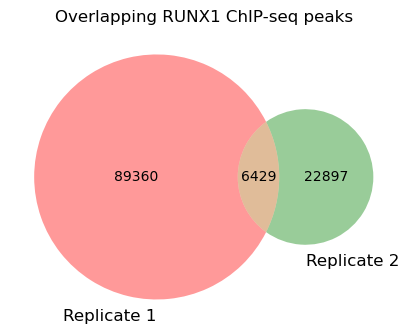

```python
# Venn diagram

import matplotlib.pyplot as plt
from matplotlib_venn import venn2


only_rep1 = 89360
only_rep2 = 22897
overlap = 6429

plt.figure(figsize=(5,5))
venn2(subsets = (only_rep1, only_rep2, overlap),
      set_labels = ('Replicate 1', 'Replicate 2'))
plt.title('Overlapping RUNX1 ChIP-seq peaks')
plt.show()
```

Venn diagram of how many reproducible peaks were used for downstream analysis.

# Table 2

Reactome Pathways 2024

| Name | P-value | Adjusted p-value | Odds Ratio | Combined score |
| --- | --- | --- | --- | --- |
| Chromatin Modifying Enzymes | 0.000003450 | 0.002915 | 2.00 | 25.13 |
| Chromatin Organization | 0.000003450 | 0.002915 | 2.00 | 25.13 |
| Formation of WDR5-containing Histone-Modifying Complexes | 0.000004719 | 0.002915 | 4.42 | 54.26 |
| Translation | 0.00002488 | 0.01153 | 1.76 | 18.70 |
| Cellular Response to Heat Stress | 0.0002404 | 0.08908 | 2.26 | 18.82 |
| Mitochondrial Translation | 0.0005842 | 0.1501 | 2.18 | 16.23 |
| HDR Through Single Strand Annealing (SSA) | 0.0006468 | 0.1501 | 3.31 | 24.33 |
| RHOBTB2 GTPase Cycle | 0.0006481 | 0.1501 | 4.45 | 32.68 |
| HDR Through Homologous Recombination (HRR) or Single Strand Annealing (SSA) | 0.0007762 | 0.1598 | 2.02 | 14.46 |
| Homology Directed Repair | 0.001002 | 0.1814 | 1.96 | 13.53 |

Table of enriched Reactome pathways found with Enrichr.

# Table 3

TF Perturbations Followed by Expression

| Name | P-value | Adjusted p-value | Odds Ratio | Combined score |
| --- | --- | --- | --- | --- |
| ZNF143 SIRNA MCF7 HUMAN GSE76453 RNASEQ UP | 6.302e-10 | 0.000001233 | 2.11 | 44.68 |
| ZMAT4 SIRNA MCF7 HUMAN GSE79586 RNASEQ UP | 2.546e-9 | 0.000002490 | 1.90 | 37.50 |
| ZNF142 SIRNA T47D HUMAN GSE79586 RNASEQ UP | 4.377e-9 | 0.000002853 | 1.84 | 35.45 |
| MYC OE MCF7 HUMAN GSE101738 RNASEQ UP | 8.137e-9 | 0.000003052 | 1.91 | 35.51 |
| ZMAT4 SIRNA T47D HUMAN GSE79586 RNASEQ UP | 8.159e-9 | 0.000003052 | 1.99 | 37.15 |
| PRRX1 SIRNA T47D HUMAN GSE79586 RNASEQ UP | 9.363e-9 | 0.000003052 | 1.81 | 33.38 |
| HOXA11 SIRNA MCF7 HUMAN GSE79586 RNASEQ UP | 1.627e-8 | 0.000004545 | 1.81 | 32.39 |
| ZNF253 SIRNA MCF7 HUMAN GSE79586 RNASEQ DOWN | 3.102e-8 | 0.000007584 | 1.88 | 32.55 |
| TSHZ3 SIRNA T47D HUMAN GSE79586 RNASEQ UP | 4.599e-8 | 0.000009996 | 1.83 | 30.89 |
| TSHZ3 SIRNA MCF7 HUMAN GSE79586 RNASEQ UP | 6.602e-8 | 0.00001229 | 1.80 | 29.83 |

Table of enriched TF perturbations followed by expression found with Enrichr.

```python
from IPython.display import Image, display
```

# Figure 3

[figure not shown]

```python
display(Image(filename='Figure2Dhg19.png'))
```

IGV view of MALAT1 peaks mapped against the hg19 reference.

# Figure 4

[figure not shown]

```python
display(Image(filename='Figure2Ehg19.png'))
```

IGV view of NEAT1 peaks mapped against the hg19 reference.

# Figure 5

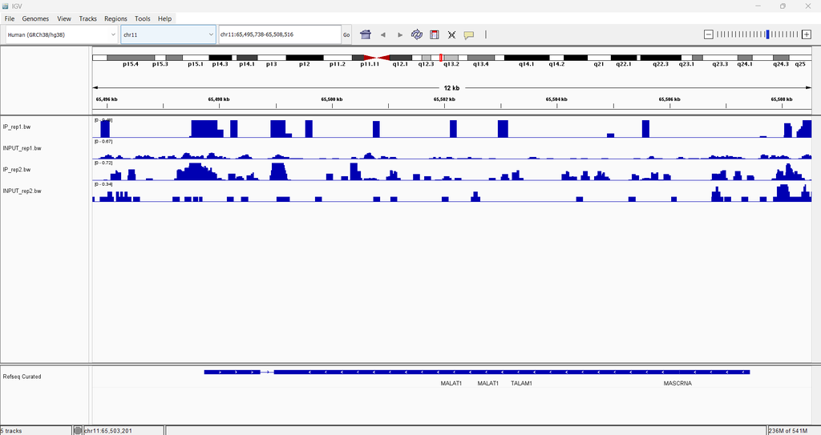

```python
display(Image(filename='Figure2D.png'))
```

IGV view of MALAT1 peaks mapped against the hg38 reference.

# Figure 6

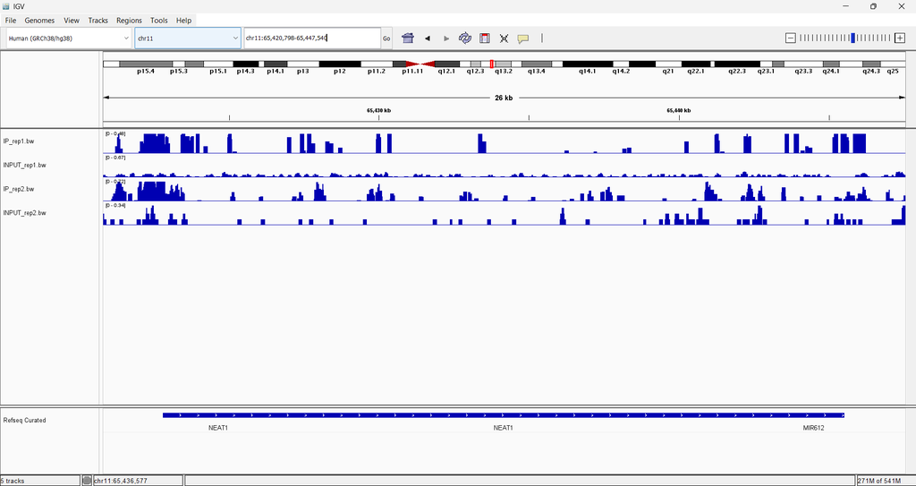

```python
display(Image(filename='Figure2E.png'))
```

IGV view of NEAT1 peaks mapped against the hg38 reference.

# Figure 7

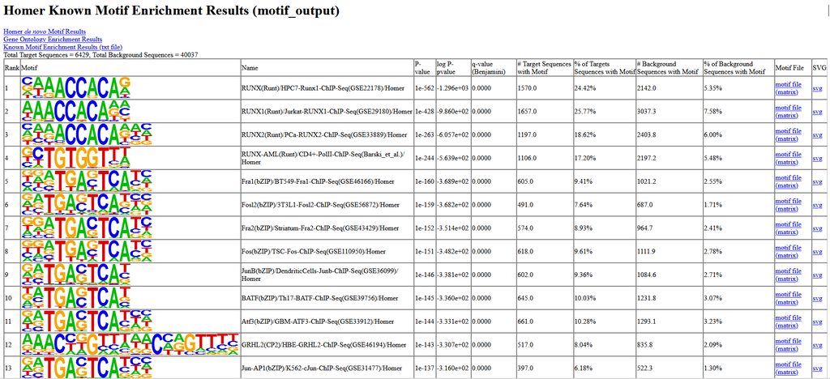

```python
display(Image(filename='KnownMotifs.png'))
```

Motifs found with HOMER. Notable motifs include that of the RUNX family, in addition to the Fos and Fra families.

# Figure 8

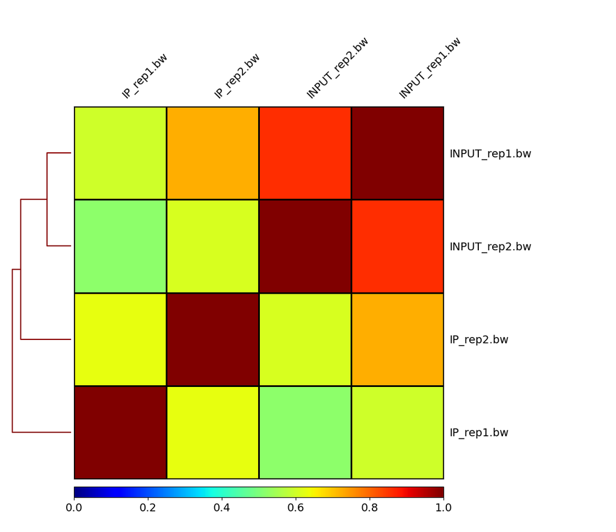

```python
display(Image(filename='correlation_plot.png'))
```

Correlation plot. The input samples cluster together, but the IP samples do not entirely cluster together.

# Figure 9

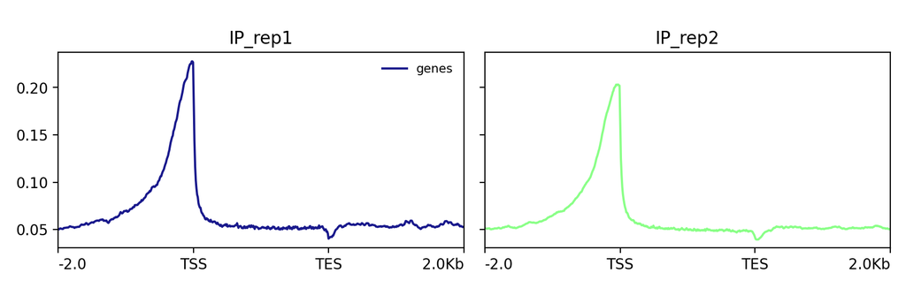

```python
display(Image(filename='signal_coverage.png'))
```

Signal coverage plot. There is an increase in intensity near the TSS, and a slight decrease in intensity at the TES.